# Incomplete Data Analysis

Stefanos Karageorgiou

10/28/2019

#Main objectives of this project In this project the main goal is to explore some of the easiest methods to handle missing data and compare their performances. The methods that we are going to test under complete case analysis are:

- Mean imputation
- Regression mean imputation
- Stochastic regression imputation
- Hot deck imputation (Predictive mean imputation)

**The data**

It is sometimes necessary to lower a patient’s blood pressure during surgery, using a hy- potensive drug. Such drugs are administrated continuously during the relevant phase of the operation; because the duration of this phase varies, so does the total amount of drug ad- ministered. Patients also vary in the extent to which the drugs succeed in lowering blood pressure. The sooner the blood pressure rises again to normal after the drug is discontinued, the better. The dataset, a partial missing value version of the data presented by Robertson and Armitage (1959), relate to a particular hypotensive drug and give the time in minutes before the patient’s systolic blood pressure returned to 1000mm of mercury (the recovery time), the logarithm (base 10) of the dose of drug in mil- ligrams (you can use this variable as is, no need to transform it to the original scale), and the average systolic blood pressure achieved while the drug was being administered.

```r
head(databp)
```

```
##   logdose bloodp recovtime R
## 1    2.26     66         7 1
## 2    1.81     52        10 1
## 3    1.78     72        18 1
## 4    1.54     67        NA 0
## 5    2.06     69        10 1
## 6    1.74     71        13 1
```

**COMPLETE CASE ANALYSIS:**

-Under complete case analysis the procedure that we follow is to exclude the full row of data for any row containing missing value (in our case in the column named “recovtime”). During the calculations we will need an indicator of missingness. We will set a variable named “indicator” which will will contain the position of the values that are observed.

```r
indicator=which(databp$R==1)
recov_mean=mean(databp$recovtime,na.rm=TRUE)
recov_se=sd(databp$recovtime,na.rm = TRUE)/sqrt(length(indicator))
recov_mean;recov_se
```

```
## [1] 19.27273
```

```
## [1] 2.603013
```

**Comment:**  
-Under complete case analysis the mean value of recovery time is 19.27273 and the associated standard error is 2.603013.

```r
recov_logd_cor=cor(databp$recovtime[indicator],databp$logdose[indicator],method = "pearson")
recov_bp_cor=cor(databp$recovtime[indicator],databp$bloodp[indicator],method="pearson")
recov_logd_cor;recov_bp_cor
```

```
## [1] 0.2391256
```

```
## [1] -0.01952862
```

**Comment:**  
Under complete case analysis the correlation between recovery time and logarithm of the dose of the drug using the Pearson method is 0.2391256 and the correlation between recovery time and blood pressure is -0.01952862.

**Imputation methods**

**1) Mean imputation**

-Mean imputation method fills all the missing data with the overall mean of the observed ones. In our case we will fill the missing data of recovery time with the mean of the observed ones. One feature of of mean imputation is that the mean of the data remains the same (equal to the mean of the observed data) after mean imputation.

```r
fulldata_m_e=ifelse(databp$R==0,recov_mean,databp$recovtime)
bmean=mean(fulldata_m_e)
bse=sd(fulldata_m_e)/sqrt(length(fulldata_m_e))
bmean;bse
```

```
## [1] 19.27273
```

```
## [1] 2.284135
```

**Comment:**  
-Via mean imputation the mean value of recovery time is 19.27273 (as expected) and the associated standard error is 2.284135. The reason that standard error is smaller than before is that by filling the missing data with the mean during the calculation of standard diviation these imputed values will be the same as mean so their difference is 0 so they dont change they dont change the sum of the differences while the denominator became bigger.

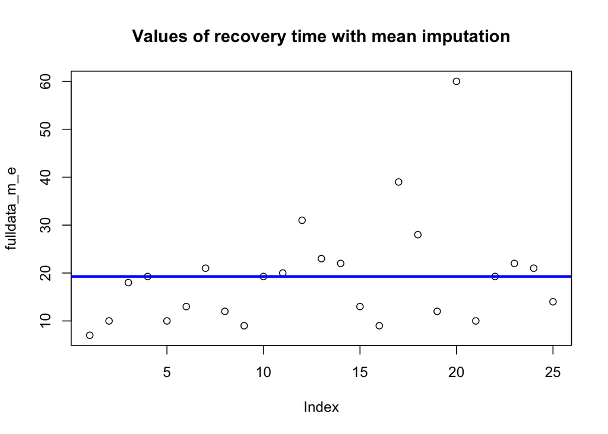

```r
plot(fulldata_m_e,main="Values of recovery time with mean imputation")
abline(h = mean(fulldata_m_e), col="blue", lwd=3)
```

```r
b_recov_logd_cor=cor(fulldata_m_e,databp$logdose,method = "pearson")
b_recov_bp_cor=cor(fulldata_m_e,databp$bloodp,method="pearson")
b_recov_logd_cor;b_recov_bp_cor
```

```
## [1] 0.2150612
```

```
## [1] -0.01934126
```

**Comment:**  
After mean imputation the correlation between recovery time and logarithm of the dose of the drug using the Pearson method is 0.2150612 and the correlation between recovery time and blood pressure is -0.01934126.

**2) Regression mean imputation**

-Regression mean imputation replaces each missing value with a predicted conditional mean from a regression equation. To do so we will fit the model only for observed values (complete case) and then predict the values of recovery time missing meaning we will fill the missing values with their predicted ones.

The regression equation will be: $recovtime=\beta_{0}+\beta_{1}logdose+\beta_{2}bloodp+\varepsilon, \varepsilon \sim N(0,\sigma^2)$

```r
fits1=lm(recovtime~logdose+bloodp,data=databp)
summary(fits1)
```

```
##
## Call:
## lm(formula = recovtime ~ logdose + bloodp, data = databp)
##
## Residuals:
##     Min      1Q  Median      3Q     Max
## -15.768 -10.250  -0.770   3.546  37.394
##
## Coefficients:
##             Estimate Std. Error t value Pr(>|t|)
## (Intercept)  15.2159    19.8203   0.768    0.452
## logdose      11.4290     8.4178   1.358    0.190
## bloodp       -0.2769     0.3411  -0.812    0.427
##
## Residual standard error: 12.25 on 19 degrees of freedom
##   (3 observations deleted due to missingness)
## Multiple R-squared:  0.08879,    Adjusted R-squared:  -0.007129
## F-statistic: 0.9257 on 2 and 19 DF,  p-value: 0.4134
```

```r
stdresiduals <- rstandard(fits1)
mean(fits1$residuals);var(fits1$residuals)
```

```
## [1] 9.386135e-16
```

```
## [1] 135.8298
```

As we can see the mean is indeed close to 0, 9.386135e-16 to be exact.

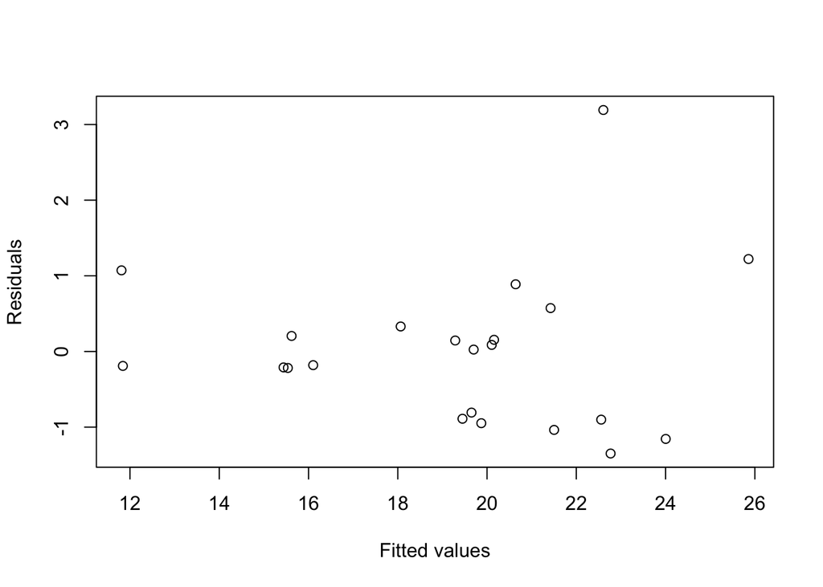

```r
plot(fits1$fitted.values, stdresiduals, xlab = "Fitted values", ylab = "Residuals")
```

-As we can see the residuals are distributed without forming any pattern almost evenly so we can assume that they hava the same variance. Next we will check the assumption of normality.

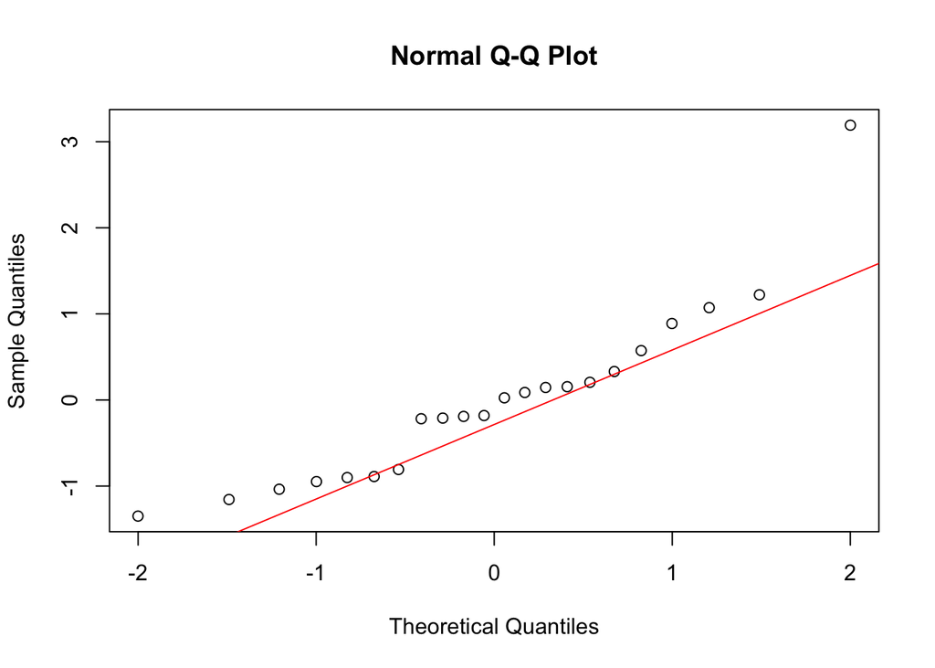

```r
qqnorm(stdresiduals)
qqline(stdresiduals,col=2)
```

```r
prediction=predict(fits1,newdata = databp)
prediction[4];prediction[10];prediction[22]
```

```
##        4
## 14.26254
```

```
##       10
## 21.51562
```

```
##       22
## 26.32896
```

```r
fulldata_r_m_e=ifelse(databp$R==0,prediction,databp$recovtime)
cmean=mean(fulldata_r_m_e)
cse=sd(fulldata_r_m_e)/sqrt(length(fulldata_r_m_e))
cmean;cse
```

```
## [1] 19.44428
```

```
## [1] 2.312845
```

**Comment:**  
-After regression mean imputation the mean value of recovery time is 19.44428 and the associated standard error is 2.312845.

```r
c_rv_logd_cor=cor(fulldata_r_m_e,databp$logdose,method = "pearson")
c_rv_bp_cor=cor(fulldata_r_m_e,databp$bloodp,method="pearson")
c_rv_logd_cor;c_rv_bp_cor
```

```
## [1] 0.2801835
```

```
## [1] -0.0111364
```

**Comment:**  
After mean regression imputation the correlation between recovery time and logarithm of the dose of the drug using the Pearson method is 0.2801835 and the correlation between recovery time and blood pressure is -0.0111364.

**3) Stochastic regression imputation**

The stochastic regression imputation is bases in the same logic as regression mean imputation with their difference being that in this case we add noise to the predictions which results on our data being more variable than before (referring to the case of regression mean imputation case). In our regression equation now we add a random variable z from a normal distribution with mean 0 and variance equal to the estimated variance of the residuals.

The equation of the predictions after adding noise will be: $\hat{recovtime}=\hat{\beta_{0}}+\hat{\beta_{1}}logdose+\hat{\beta_{2}}bloodp+\zeta, \zeta \sim N(0,\hat{\sigma}^2)$ where $\hat{\sigma}=12.25266$ the standard diviation of the residuals.

**Comment:**  
In our case we need to remember that adding a noise with variance around mean zero can result to negative predictions which in our case are predictions associated with recovery time. So naturally predictions with negative time do not make any sense. So in case we end up with a negative prediction we should generate new ones with possitive values. In our case after checking the predictions we see that all of them are positive so there is no need to do any further actions.

```r
set.seed(3)
prediction2=predict(fits1,newdata = databp)+rnorm(length(fulldata_r_m_e),0,sigma(fits1))
prediction2[4];prediction2[10];prediction2[22]
```

```
##         4
## 0.1458566
```

```
##       10
## 37.04426
```

```
##       22
## 14.78327
```

```r
fulldata_s_r_i=ifelse(databp$R==0,prediction2,databp$recovtime)
dmean=mean(fulldata_s_r_i)
dse=sd(fulldata_s_r_i)/sqrt(length(fulldata_s_r_i))
dmean;dse
```

```
## [1] 19.03894
```

```
## [1] 2.526795
```

**Comment:**  
-After stochastis regression imputation the mean value of recovery time is 19.03894 and the associated standard error is 2.526795.

```r
d_rv_logd_cor=cor(fulldata_s_r_i,databp$logdose,method = "pearson")
d_rv_bp_cor=cor(fulldata_s_r_i,databp$bloodp,method="pearson")
d_rv_logd_cor;d_rv_bp_cor
```

```
## [1] 0.2924831
```

```
## [1] 0.02125841
```

**4) Hot deck imputation (Predictive mean imputation).**

In general hot deck imputation implies that we replace a missing value by replacing it randomly with one fully observed value which has the same specified characteristics. In our case we will chose a donor based on the one that has the prediction with the smallest squared difference with the prediction of our missing data. In the following code we search the minimum square difference between each observed value and our missing value at a time. Following to that, we then seek the position of the observed value which had the minimum prediction difference with the prediction of our missing value. By locating the subject we then assign its real value to the missing value. This process occurs 3 times (the number of our missing values). One notice about the code is that in the which function we get as a result a named integer. That is happening because the original column of predictions has length 25 and we use it in 2 pieces. So the which function returns the position of the prediction in the original column as a name and then the value of the current position(ie the position of the prediction if we had a column only with predicitions of observed values meaning a column with a length of 22). For example for the donor 4 we see that the closest prediction is the one of the one with the position 6. However we ask the which function to specify as which prediction of observed values is the one that contirbutes to the minimum difference. So now the position 6 is 5 because the position 4 (which is missing value) is been excluded from the column. Thus when we assign which we get a names integer with the name 6(original position) and value 5(position after excluding missing values) and that is why we then assign the numeric value of positions name as the donor.

```r
missingd=which(databp$R==0)
observed=which(databp$R==1)

min1=min((prediction[observed]-prediction[missingd][1])^2)
min1
```

```
## [1] 1.387919
```

```r
position1=which((prediction[observed]-prediction[missingd][1])^2==min1)
donor4=as.numeric(names(position1))
donor4
```

```
## [1] 6
```

```r
min2=min((prediction[observed]-prediction[missingd][2])^2)
min2
```

```
## [1] 0.0001781892
```

```r
position2=which((prediction[observed]-prediction[missingd][2])^2==min2)
donor10=as.numeric(names(position2))
donor10
```

```
## [1] 2
```

```r
min3=min((prediction[observed]-prediction[missingd][3])^2)
min3
```

```
## [1] 0.2211915
```

```r
position3=which((prediction[observed]-prediction[missingd][3])^2==min3)
donor22=as.numeric(names(position3))
donor22
```

```
## [1] 17
```

```r
fulldata_h_d=c(databp$recovtime[databp$R==1],databp$recovtime[donor4],databp$recovtime[donor10],databp$recovtime[donor22])

emean=mean(fulldata_h_d)
ese=sd(fulldata_h_d)/sqrt(length(fulldata_h_d))
emean;ese
```

```
## [1] 19.44
```

```
## [1] 2.464467
```

**Comment:**  
After using the method of predictive mean imputation the minimum differences between missing value with the position 4 was 1.387919 and the position of the correspondant donor is 6. For the missing value with position 10 the minimum squared difference was 0.0001781892 and the correspondant donor is 2. Finally the for missing value with position 22 the minimum difference was 0.2211915 occuring through the observed data of the one with the position 17. The resulting mean of recovery time after using this method is 19.44 and the standard error is 2.464467.

**Comment:**  
Right now the order of our column recovery time is not the same as before as we imputed the donor values at the end of the list. That means that we cannot align the recovery time with other columns with the recovery time being as it is. The correlation formula of Pearson is in the form of : $r_{xy}=\frac{n\sum_{i=1}^{n}(x_{i}-\overline{\rm x})(y_{i}-\overline{\rm y})}{\sqrt\sum_{i=1}^{n}(x_{i}-\overline{\rm x})^2\sqrt\sum_{i=1}^{n}(y_{i}-\overline{\rm y})^2}$ , which verifies that we need to have our data ordered. So we will first order our column and then calculate the correlations.

```r
library(dplyr)
library(zoo)
```

```r
fulldataordered=case_when(
  index(databp$recovtime)==4 ~ databp$recovtime[6],
  index(databp$recovtime)==10 ~ databp$recovtime[2],
  index(databp$recovtime)==22 ~ databp$recovtime[17],
  TRUE ~ databp$recovtime)

e_rv_logd_cor=cor(fulldataordered,databp$logdose,method = "pearson")
e_rv_bp_cor=cor(fulldataordered,databp$bloodp,method="pearson")
e_rv_logd_cor;e_rv_bp_cor
```

```
## [1] 0.3037945
```

```
## [1] -0.03208685
```

**Comment:**  
After predictive mean imputation the correlation between recovery time and logarithm of the dose of the drug using the Pearson method is 0.3037945 and the correlation between recovery time and blood pressure is -0.03208685.

**Advantages and potentional problems of predictive mean matching over stochastic regression imputation.**

- The main advantage we can clearly see versus stochastic regression imputation is that the imputations over this method are already observed values. That means that we will not have same problems with meaningless imputations that may occur in the stochastic method such as negative ones.
- A possible problem of predictive mean matching over a big data sample may occur in the case of a larger data set where our minimum difference for a missing value is found in more than one positions. As we can see above we chose to replace a missing value of recovery time which has logdose and bloodpressure values with one observed value with different characteristics. If we have more than one positions where we found the minimum difference then we are obliged by the hot deck method to chose one randomly. That may results to very different replacement of the missing value.

Thanks for reading!